# Question

In a deck of strange cards, there are 479 cards. Each card has an image and a color.

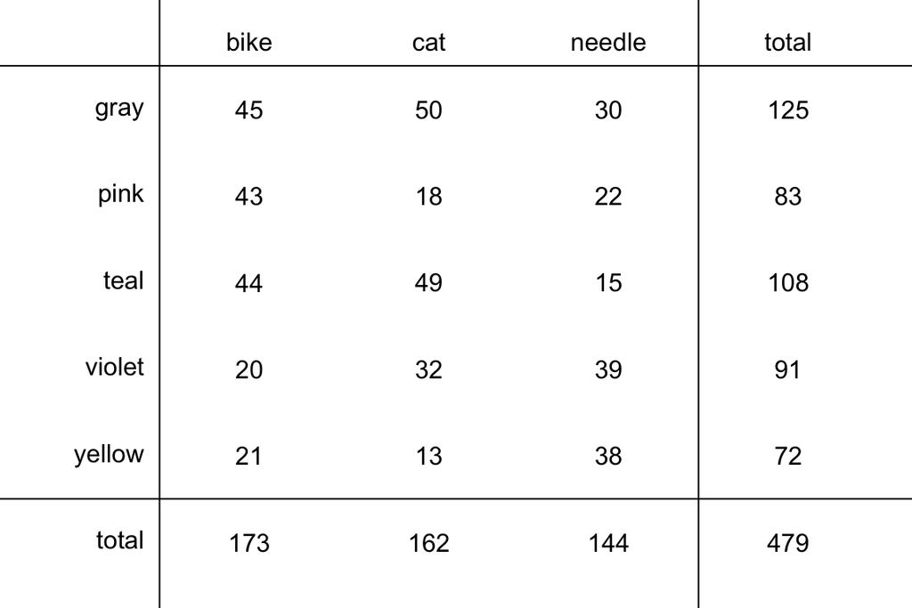

1. What is the probability a random card is a needle? ##ANSWER1##
2. What is the probability a random card is teal? ##ANSWER2##
3. What is the probability a random card is both a cat and yellow? ##ANSWER3##
4. What is the probability a random card is either a cat or gray (or both)? ##ANSWER4##
5. What is the probability a random card is yellow given it is a needle? ##ANSWER5##
6. What is the probability a random card is a needle given it is teal? ##ANSWER6##
7. Between a bike and a needle, which is more likely to be a violet? ##ANSWER7##

## Answerlist

- 0.07
- 0.30
- 0.63
- 0.73
- 0.05
- 0.08
- 0.12
- 0.23
- 0.03
- 0.08
- 0.37
- 0.65
- 0.01
- 0.40
- 0.49
- 0.55
- 0.05
- 0.07
- 0.26
- 0.66
- 0.14
- 0.35
- 0.64
- 0.76
- A bike.
- A needle.

# Solution

[video](https://vimeo.com/531915456)

The key logical terms are “[and](https://en.wikipedia.org/wiki/Logical_conjunction)”, “[or](https://en.wikipedia.org/wiki/Logical_disjunction)”, and “[given](https://en.wikipedia.org/wiki/Conditional_probability)”. Notice that I am using “given” as a shorter version of “under the condition”.

1. $\mathbb{P}[\text{needle}]=\frac{144}{479}=0.3$
2. $\mathbb{P}[\text{teal}]=\frac{108}{479}=0.23$
3. $\mathbb{P}[\text{cat and yellow}]=\frac{13}{479}=0.03$
4. $\mathbb{P}[\text{cat or gray}]=\frac{162+125-50}{479}=0.49$
5. $\mathbb{P}[\text{yellow given needle}]=\frac{38}{144}=0.26$
6. $\mathbb{P}[\text{needle given teal}]=\frac{15}{108}=0.14$
7. $\mathbb{P}[\text{violet given bike}] = 0.12$ and $\mathbb{P}[\text{violet given needle}] = 0.27$, so a needle is more likely to be violet than a bike is.

# Meta-information

extype: cloze exsolution: 0100|0001|1000|0010|0010|1000|01 exclozetype: schoice|schoice|schoice|schoice|schoice|schoice|schoice exname: Cards_probabilities